# TS-MT_revisions

Nikita Verheyden

JLU Giessen

22 February 2024

# 1 Setup

dir

```r
setwd("C:/Users/nikit/Documents/Krueger_Lab/Publications/miR181_paper_revisions/TS-MT_plots")
```

## 1.1 packages

```r
source("C:/Users/nikit/Documents/Krueger_Lab/Publications/miR181_paper/Supporting_scripts/themes/theme_paper.R")
library(readxl)
library(eulerr)
library(dplyr)
```

```r
library(ggplot2)
library(ggpubr)
library(biomaRt)
```

## 1.2 data

```r
# Targetscan
TS <- as.data.frame(read_xlsx("TargetScan7.2__miR-181-5p.predicted_targets.xlsx"))

head(TS)
```

```
##     Target gene Representative transcript                  Gene name
## 1         Zfp97      ENSMUST00000147630.1     zinc finger protein 97
## 2        Zfp960      ENSMUST00000127027.1    zinc finger protein 960
## 3       Gm14420      ENSMUST00000108952.3       predicted gene 14420
## 4        Gm6710      ENSMUST00000109012.3        predicted gene 6710
## 5 9830147E19Rik      ENSMUST00000098503.3 RIKEN cDNA 9830147E19 gene
## 6       Gm14431      ENSMUST00000178443.1       predicted gene 14431
##   3P-seq tags + 5 Conserved sites total Conserved 8mer sites
## 1               5                     3                    3
## 2               5                     2                    2
## 3               0                     3                    3
## 4               0                     1                    1
## 5               2                     4                    4
## 6               0                     4                    3
##   Conserved 7mer-m8 sites Conserved 7mer-A1 sites Poorly conserved sites total
```

[output cut: 34 more lines]

```r
# miRTarBase
MT <- read.csv("all-miR-181_mirtarbase.csv")
#only use a and b
MTab <- MT[MT$miRNA %in% c("mmu-miR-181a", "mmu-miR-181b", "mmu-miR-181a-5p", "mmu-miR-181b-5p"),]

head(MTab)
```

```
##            ID Species.miRNA. Species.Target.        miRNA Target Reporter.assay
## 2  MIRT752261            mmu             mmu mmu-miR-181a  Ap1g1              0
## 4  MIRT752263            mmu             mmu mmu-miR-181b  Ap1g1              0
## 7  MIRT746725            mmu             mmu mmu-miR-181b   Aqp3              0
## 8  MIRT746726            mmu             mmu mmu-miR-181a   Aqp3              0
## 9  MIRT750537            mmu             mmu mmu-miR-181a Atp2a2              0
## 10 MIRT750538            mmu             mmu mmu-miR-181b Atp2a2              0
##    Western.blot qPCR Microarray NGS pSILAC Other CLIP.Seq Sum Number.of.paper
## 2             0    0          0   0      0     0        1   1               1
## 4             0    0          0   0      0     0        1   1               1
## 7             0    0          0   0      0     0        1   1               2
## 8             0    0          0   0      0     0        1   1               2
## 9             0    0          0   0      0     0        1   1               1
## 10            0    0          0   0      0     0        1   1               1
```

```r
# miR-eCLIP
larget <- readRDS("C:/Users/nikit/Documents/Krueger_Lab/Publications/miR181_paper/Figure5/01_Seed_motifes/mir181_bs_with_seeds_transcripts.rds")
largetframe <- as.data.frame(larget)
largetframenf <- largetframe
table(largetframe$set)
```

```
##
##                 ago_bs_mir181_chi ago_bs_mir181_chi&mir181_enriched
##                              5725                              1061
##                   mir181_enriched
##                              3458
```

```r
largetframe <- largetframe %>%
  subset(set %in% c("ago_bs_mir181_chi&mir181_enriched", "mir181_enriched"))
head(largetframe)
```

```
##                seqnames start  end width strand xHits transcriptsHits  scoreSum
## 3246 ENSMUST00000162257  1754 1760     7      *  3265              51 30.310850
## 3247 ENSMUST00000182675   525  531     7      *  3266              84  9.214680
## 3248 ENSMUST00000115174  1773 1779     7      *  3267             390  7.169806
## 3249 ENSMUST00000027252  4704 4710     7      *  3268             565 30.169900
## 3250 ENSMUST00000168431  4695 4701     7      *  3269             606 69.097090
## 3251 ENSMUST00000168431  5440 5446     7      *  3270             606 30.339340
##      scoreMean scoreMax                  geneType geneName             geneID
## 3246 10.103617 17.15080 mature protein_coding RNA   Rb1cc1 ENSMUSG00000025907
## 3247  3.071560  5.53318 mature protein_coding RNA   Pcmtd1 ENSMUSG00000051285
## 3248  1.433961  5.00224 mature protein_coding RNA    Rab23 ENSMUSG00000004768
## 3249 15.084950 16.74820 mature protein_coding RNA    Eif5b ENSMUSG00000026083
## 3250 23.032363 56.37730 mature protein_coding RNA   Map4k4 ENSMUSG00000026074
## 3251  7.584835 17.14600 mature protein_coding RNA   Map4k4 ENSMUSG00000026074
##      region mir_IP n_mir181 n_mir181a n_mir181b n_mir181c n_mir181d
```

[output cut: 97 more lines]

```r
#Ribo profiling
RNA <- read.csv("C:/Users/nikit/Documents/Krueger_Lab/Publications/miR181_paper/Figure3/01_Ribosome_profiling_pipeline/RNA_masterframe.csv")
RPF <- read.csv("C:/Users/nikit/Documents/Krueger_Lab/Publications/miR181_paper/Figure3/01_Ribosome_profiling_pipeline/RPF_masterframe.csv")


RNAnolim <- read.csv("C:/Users/nikit/Documents/Krueger_Lab/Publications/miR181_paper/Figure3/01_Ribosome_profiling_pipeline/RNA_masterframe_nocutoff.csv")
RPFnolim <- read.csv("C:/Users/nikit/Documents/Krueger_Lab/Publications/miR181_paper/Figure3/01_Ribosome_profiling_pipeline/RPF_masterframe_nocutoff.csv")
```

## 1.3 colours

```r
#colours
farbeneg <- "#b4b4b4"
farbe1 <- "#0073C2FF"
farbe2 <- "#EFC000FF"
farbe3 <- "#CD534CFF"
farbe4 <- "#7AA6DCFF"
farbe5 <- "#868686FF"
farbe6 <- "#003C67FF"
farbe7 <- "#8F7700FF"
farbe8 <- "#3B3B3BFF"
farbe9 <- "#A73030FF"
farbe10 <- "#4A6990FF"
farbe11 <- "#FF6F00FF"
farbe12 <- "#C71000FF"
farbe13 <- "#008EA0FF"
farbe14 <- "#8A4198FF"
farbe15 <- "#5A9599FF"
farbe16 <- "#FF6348FF"

RNApcol <- "#b56504"
RNAncol <- "#027d73"
RPFpcol <- "#c4c404"
RPFncol <- "#8d0391"
```

# 2 Overlap miRTarBase and TargetScan

## 2.1 Make overlap list

```r
ollist <- list(TS[!duplicated(TS$`Target gene`), "Target gene"],
               MTab[!duplicated(MTab$Target), "Target"])
names(ollist) <- c("TargetScan", "miRTarBase")
```

## 2.2 Plot

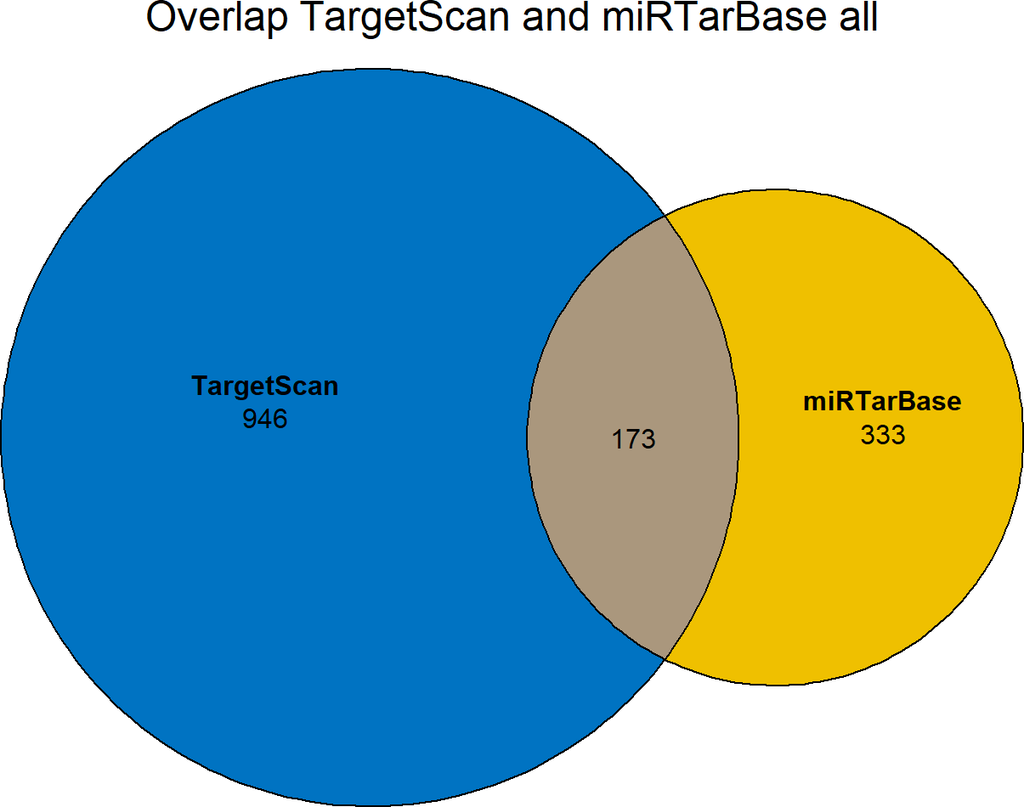

```r
plot(euler(ollist, shape="ellipse"), quantities = T, fills=c(farbe1, farbe2), main = "Overlap TargetScan and miRTarBase all")
```

```r
pdf("Venn_Overlap TargetScan and miRTarBase all.pdf", width = 3, height = 3)
plot(euler(ollist, shape="ellipse"), quantities = T, fills=c(farbe1, farbe2), main = "Overlap TargetScan and miRTarBase all")
dev.off()
```

# 3 Overlap databases with miR-eCLIP

## 3.1 List

```r
cliplist <- list(TS[!duplicated(TS$`Target gene`), "Target gene"],
               MTab[!duplicated(MTab$Target), "Target"],
               largetframe[!duplicated(largetframe$geneName), "geneName"])
names(cliplist) <- c("TargetScan", "miRTarBase", "miR-eCLIP")

TSlist <- list(TS[!duplicated(TS$`Target gene`), "Target gene"],
               largetframe[!duplicated(largetframe$geneName), "geneName"])
names(TSlist) <- c("TargetScan", "miR-eCLIP")

MTlist <- list(MTab[!duplicated(MTab$Target), "Target"],
               largetframe[!duplicated(largetframe$geneName), "geneName"])
names(MTlist) <- c("miRTarBase", "miR-eCLIP")
```

## 3.2 Venn diagram

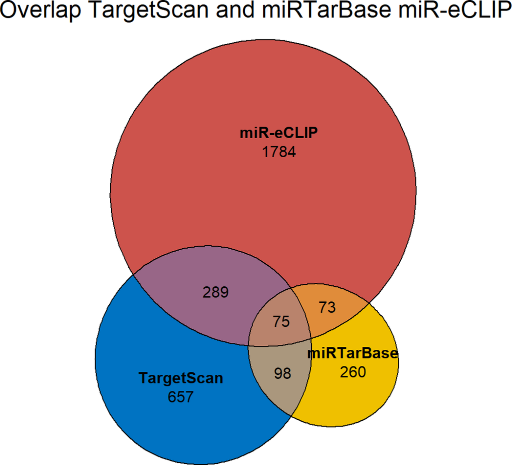

```r
# all 3
plot(euler(cliplist, shape="ellipse"), quantities = T, fills=c(farbe1, farbe2, farbe3), main = "Overlap TargetScan and miRTarBase miR-eCLIP")
```

```r
pdf("Venn_Overlap TargetScan miRTarBase and miR-eCLIP all.pdf", width = 3, height = 3)
plot(euler(cliplist, shape="ellipse"), quantities = T, fills=c(farbe1, farbe2, farbe3), main = "Overlap TargetScan and miRTarBase miR-eCLIP")
dev.off()
```

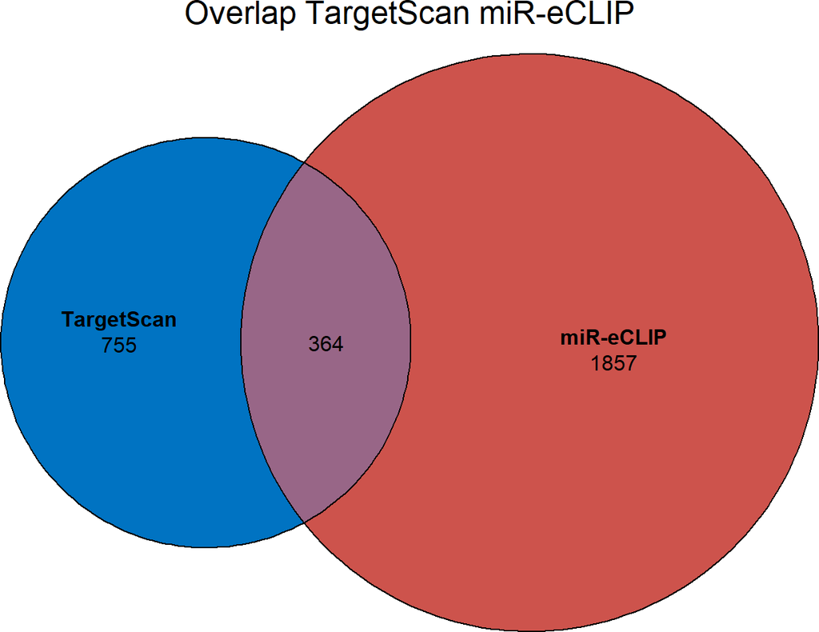

```r
# eclip+targetscan
plot(euler(TSlist, shape="ellipse"), quantities = T, fills=c(farbe1,  farbe3), main = "Overlap TargetScan miR-eCLIP")
```

```r
pdf("Venn_Overlap TargetScan and miR-eCLIP all.pdf", width = 3, height = 3)
plot(euler(TSlist, shape="ellipse"), quantities = T, fills=c(farbe1, farbe3), main = "Overlap TargetScan miR-eCLIP")
dev.off()
```

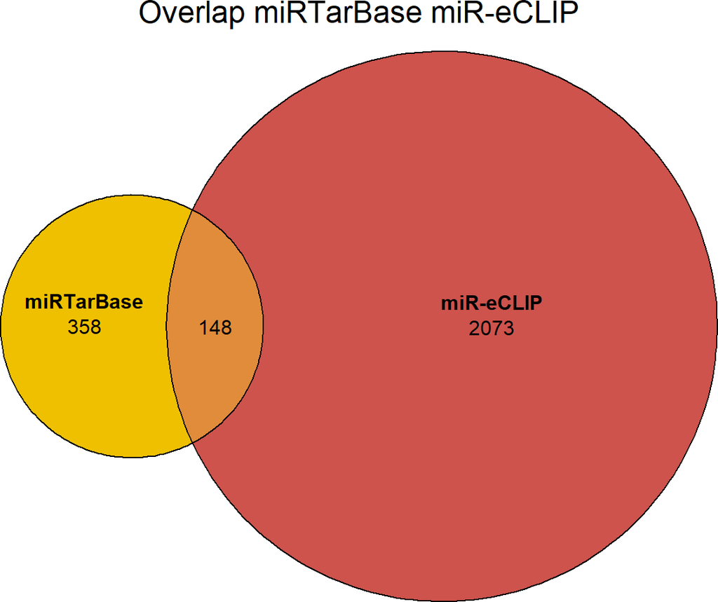

```r
# eclip+mirtarbase
plot(euler(MTlist, shape="ellipse"), quantities = T, fills=c(farbe2, farbe3), main = "Overlap miRTarBase miR-eCLIP")
```

```r
pdf("Venn_Overlap miRTarBase and miR-eCLIP all.pdf", width = 3, height = 3)
plot(euler(MTlist, shape="ellipse"), quantities = T, fills=c(farbe2, farbe3), main = "Overlap miRTarBase miR-eCLIP")
dev.off()
```

# 4 overlap venn plot without any filters (also includes all sets of targets we had)

we removed one set initially, if we dont want to see that (ask kathi), the previous plot is already the correct one

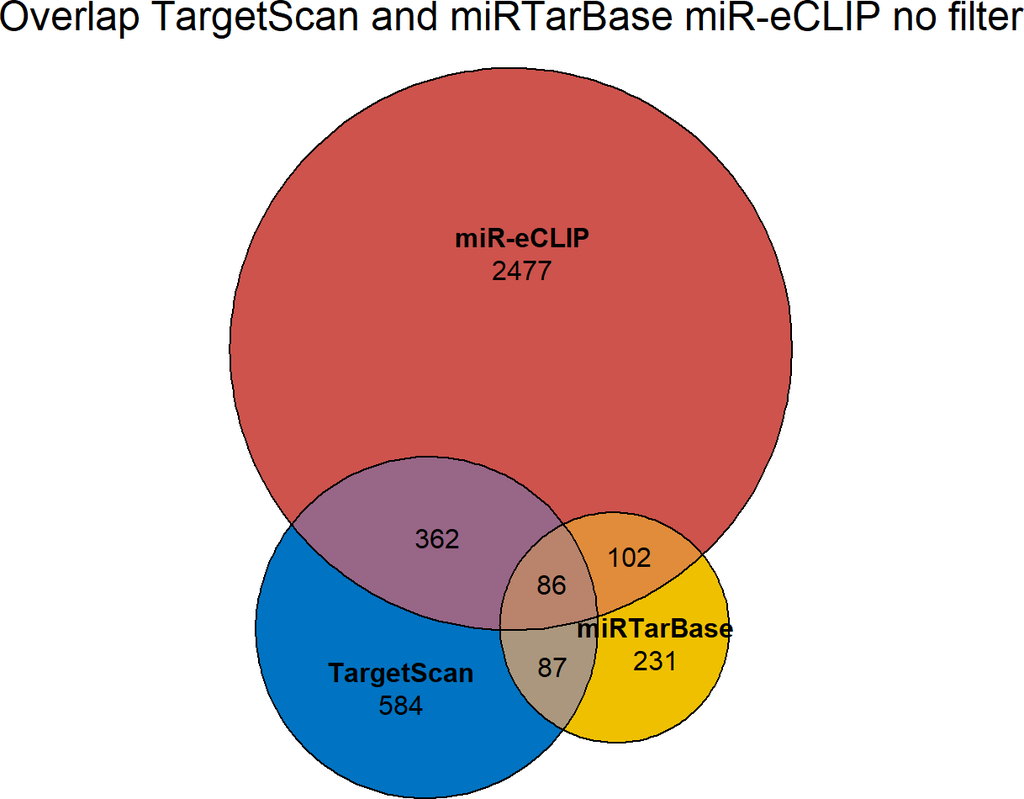

```r
cliplistnf <- list(TS[!duplicated(TS$`Target gene`), "Target gene"],
               MTab[!duplicated(MTab$Target), "Target"],
               largetframenf[!duplicated(largetframenf$geneName), "geneName"])
names(cliplistnf) <- c("TargetScan", "miRTarBase", "miR-eCLIP")

plot(euler(cliplistnf, shape="ellipse"), quantities = T, fills=c(farbe1, farbe2, farbe3), main = "Overlap TargetScan and miRTarBase miR-eCLIP no filter")
```

```r
pdf("Venn_Overlap TargetScan miRTarBase and miR-eCLIP all no filter.pdf", width = 3, height = 3)
plot(euler(cliplistnf, shape="ellipse"), quantities = T, fills=c(farbe1, farbe2, farbe3), main = "Overlap TargetScan and miRTarBase miR-eCLIP no filter")
dev.off()
```

## 4.1 ECDF plots

### 4.1.1 No duplicates

### 4.1.2 partial lists

```r
MTo <- MTab[!duplicated(MTab$Target) &
              !(MTab$Target %in% largetframe$geneName) &
              !(MTab$Target %in% TS$`Target gene`), "Target"]

eclipo <- largetframe[!duplicated(largetframe$geneName) &
              !(largetframe$geneName %in% TS$`Target gene`) &
              !(largetframe$geneName %in% MTab$Target), "geneName"]

TSo <- TS[!duplicated(TS$`Target gene`) &
            !(TS$`Target gene` %in% largetframe$geneName) &
            !(TS$`Target gene` %in% MTab$Target), "Target gene"]

elcipTS <- largetframe[!duplicated(largetframe$geneName) &
              (largetframe$geneName %in% TS$`Target gene`) &
              !(largetframe$geneName %in% MTab$Target), "geneName"]

eclipMT <- largetframe[!duplicated(largetframe$geneName) &
              !(largetframe$geneName %in% TS$`Target gene`) &
              (largetframe$geneName %in% MTab$Target), "geneName"]

TSMT <- TS[!duplicated(TS$`Target gene`) &
            !(TS$`Target gene` %in% largetframe$geneName) &
            (TS$`Target gene` %in% MTab$Target), "Target gene"]

eclipTSMT<- largetframe[!duplicated(largetframe$geneName) &
              (largetframe$geneName %in% TS$`Target gene`) &
              (largetframe$geneName %in% MTab$Target), "geneName"]
```

### 4.1.3 Add IDs to RNA and RF

```r
RNA$Overlap_all <- "Non-target"
RNA$Overlap_all[RNA$gene_symbol %in% MTo] <- "MT"
RNA$Overlap_all[RNA$gene_symbol %in% eclipo] <- "eCLIP"
RNA$Overlap_all[RNA$gene_symbol %in% TSo] <- "TS"
RNA$Overlap_all[RNA$gene_symbol %in% elcipTS] <- "eCLIP & TS"
RNA$Overlap_all[RNA$gene_symbol %in% eclipMT] <- "eCLIP & MT"
RNA$Overlap_all[RNA$gene_symbol %in% TSMT] <- "TS & MT"
RNA$Overlap_all[RNA$gene_symbol %in% eclipTSMT] <- "eCLIP, TS & MT"

RPF$Overlap_all <- "Non-target"
RPF$Overlap_all[RPF$gene_symbol %in% MTo] <- "MT"
RPF$Overlap_all[RPF$gene_symbol %in% eclipo] <- "eCLIP"
RPF$Overlap_all[RPF$gene_symbol %in% TSo] <- "TS"
RPF$Overlap_all[RPF$gene_symbol %in% elcipTS] <- "eCLIP & TS"
RPF$Overlap_all[RPF$gene_symbol %in% eclipMT] <- "eCLIP & MT"
RPF$Overlap_all[RPF$gene_symbol %in% TSMT] <- "TS & MT"
RPF$Overlap_all[RPF$gene_symbol %in% eclipTSMT] <- "eCLIP, TS & MT"
```

### 4.1.4 ECDF plots

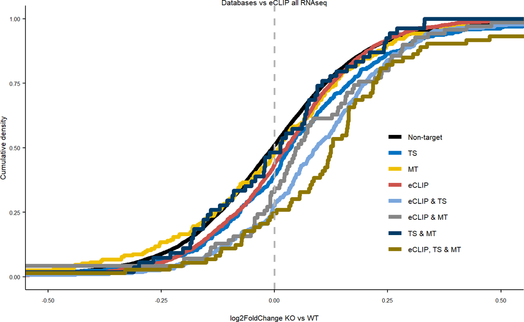

```r
#limits
xlim <- 0.5
#RNA
OLaecdfRNA <- ggplot(RNA, aes(as.numeric(log2FoldChange), colour=factor(Overlap_all,
                                                                        levels = c("Non-target", "TS", "MT", "eCLIP", "eCLIP & TS", "eCLIP & MT", "TS & MT", "eCLIP, TS & MT")))) +
  stat_ecdf(geom="step", linewidth=2) +
  geom_vline(xintercept = 0, linewidth=1, linetype="dashed", colour=farbeneg) +
  scale_colour_manual(values = c("black", farbe1, farbe2, farbe3, farbe4, farbe5, farbe6, farbe7)) +
  coord_cartesian(xlim = c(-xlim, xlim)) +
  theme_paper() +
  scale_y_continuous("Cumulative density") + scale_x_continuous("log2FoldChange KO vs WT") +
  ggtitle("Databases vs eCLIP all RNAseq")
OLaecdfRNA
```

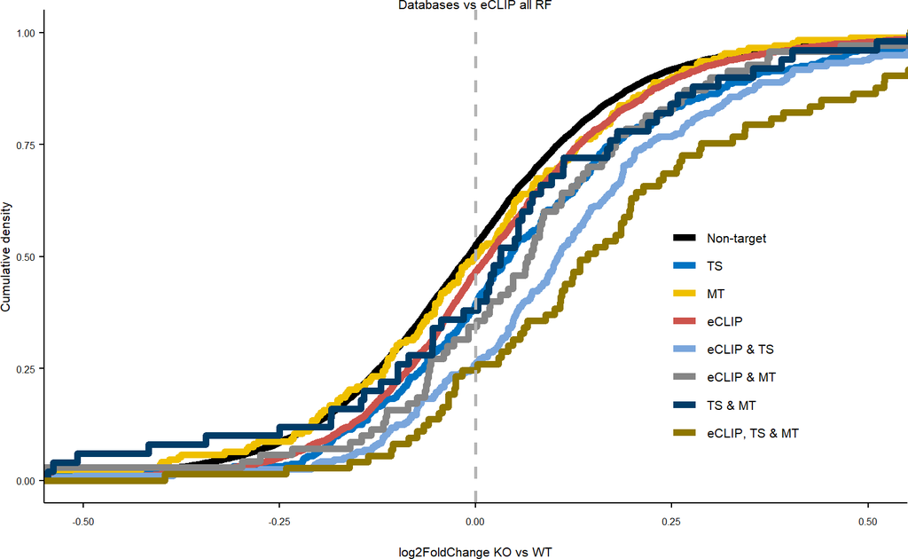

```r
OLaecdfRPF <- ggplot(RPF, aes(as.numeric(log2FoldChange), colour=factor(Overlap_all,
                                                                        levels = c("Non-target", "TS", "MT", "eCLIP", "eCLIP & TS", "eCLIP & MT", "TS & MT", "eCLIP, TS & MT")))) +
  stat_ecdf(geom="step", linewidth=2) +
  geom_vline(xintercept = 0, linewidth=1, linetype="dashed", colour=farbeneg) +
  scale_colour_manual(values = c("black", farbe1, farbe2, farbe3, farbe4, farbe5, farbe6, farbe7)) +
  coord_cartesian(xlim = c(-xlim, xlim)) +
  theme_paper() +
  scale_y_continuous("Cumulative density") + scale_x_continuous("log2FoldChange KO vs WT") +
  ggtitle("Databases vs eCLIP all RF")

OLaecdfRPF
```

```r
pdf("TS_MT_eCLIP_all_ECDF_RNA.pdf", width=2, height = 2)
OLaecdfRNA
dev.off()
```

```r
pdf("TS_MT_eCLIP_all_ECDF_RF.pdf", width=2, height = 2)
OLaecdfRPF
dev.off()
```

# 5 no duplicates split by MT and TS

### 5.0.1 partial lists

```r
#MT
MTomt <- MTab[!duplicated(MTab$Target) &
                !(MTab$Target %in% largetframe$geneName), "Target"]

eclipomt <- largetframe[!duplicated(largetframe$geneName) &
                     !(largetframe$geneName %in% MTab$Target), "geneName"]

mtclipmt <- largetframe[!duplicated(largetframe$geneName) &
                     largetframe$geneName %in% MTab$Target, "geneName"]

#TS
TSots <- TS[!duplicated(TS$`Target gene`) &
                !(TS$`Target gene` %in% largetframe$geneName), "Target gene"]

eclipots <- largetframe[!duplicated(largetframe$geneName) &
                     !(largetframe$geneName %in% TS$`Target gene`), "geneName"]

tsclipts <- largetframe[!duplicated(largetframe$geneName) &
                     largetframe$geneName %in% TS$`Target gene`, "geneName"]
```

### 5.0.2 Add IDs to RNA and RF

```r
RNA$mirtarbase <- "Non-target"
RNA$mirtarbase[RNA$gene_symbol %in% MTomt] <- "MT"
RNA$mirtarbase[RNA$gene_symbol %in% eclipomt] <- "miR-eCLIP"
RNA$mirtarbase[RNA$gene_symbol %in% mtclipmt] <- "Both"

RNA$targetscan <- "Non-target"
RNA$targetscan[RNA$gene_symbol %in% TSots] <- "TS"
RNA$targetscan[RNA$gene_symbol %in% eclipots] <- "miR-eCLIP"
RNA$targetscan[RNA$gene_symbol %in% tsclipts] <- "Both"


RPF$mirtarbase <- "Non-target"
RPF$mirtarbase[RPF$gene_symbol %in% MTomt] <- "MT"
RPF$mirtarbase[RPF$gene_symbol %in% eclipomt] <- "miR-eCLIP"
RPF$mirtarbase[RPF$gene_symbol %in% mtclipmt] <- "Both"

RPF$targetscan <- "Non-target"
RPF$targetscan[RPF$gene_symbol %in% TSots] <- "TS"
RPF$targetscan[RPF$gene_symbol %in% eclipots] <- "miR-eCLIP"
RPF$targetscan[RPF$gene_symbol %in% tsclipts] <- "Both"
```

### 5.0.3 ECDF plots

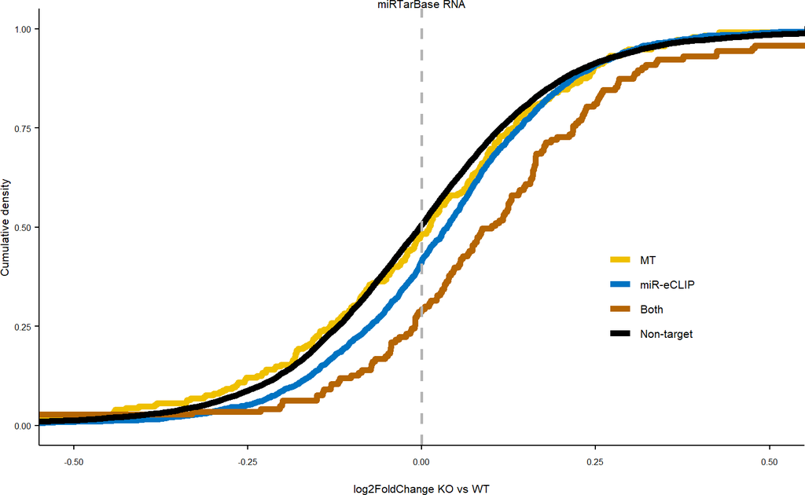

```r
#limits
xlim <- 0.5

#RNA
##MT

MTRNAplot <- ggplot(RNA, aes(as.numeric(log2FoldChange), colour=factor(mirtarbase,
                                                                        levels = c("MT", "miR-eCLIP", "Both", "Non-target")))) +
  stat_ecdf(geom="step", linewidth=2) +
  geom_vline(xintercept = 0, linewidth=1, linetype="dashed", colour=farbeneg) +
  scale_colour_manual(values = c(farbe2, farbe1, RNApcol, "black")) +
  coord_cartesian(xlim = c(-xlim, xlim)) +
  theme_paper() +
  scale_y_continuous("Cumulative density") + scale_x_continuous("log2FoldChange KO vs WT") +
  ggtitle("miRTarBase RNA")

MTRNAplot
```

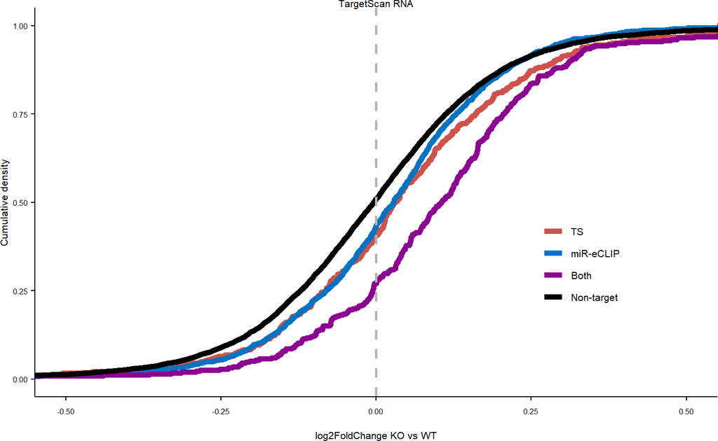

```r
##TS
TSRNAplot <- ggplot(RNA, aes(as.numeric(log2FoldChange), colour=factor(targetscan,
                                                                        levels = c("TS", "miR-eCLIP", "Both", "Non-target")))) +
  stat_ecdf(geom="step", linewidth=2) +
  geom_vline(xintercept = 0, linewidth=1, linetype="dashed", colour=farbeneg) +
  scale_colour_manual(values = c(farbe3, farbe1, RPFncol, "black")) +
  coord_cartesian(xlim = c(-xlim, xlim)) +
  theme_paper() +
  scale_y_continuous("Cumulative density") + scale_x_continuous("log2FoldChange KO vs WT") +
  ggtitle("TargetScan RNA")

TSRNAplot
```

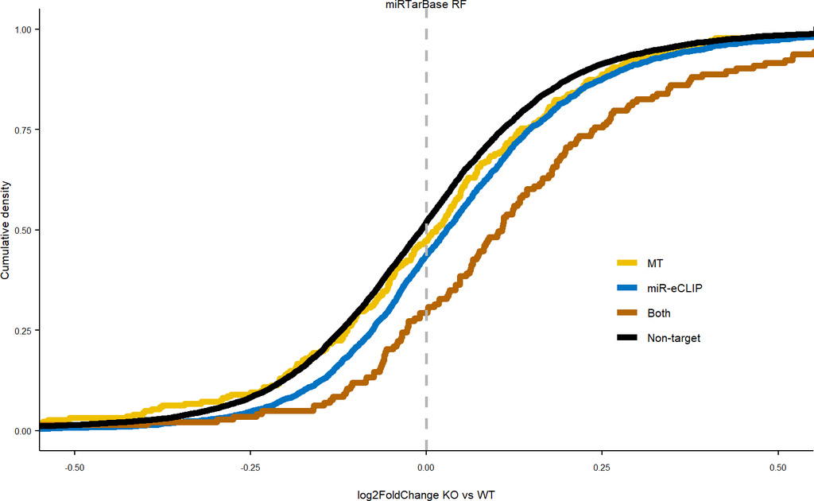

```r
#RPF
##MT

MTRPFplot <- ggplot(RPF, aes(as.numeric(log2FoldChange), colour=factor(mirtarbase,
                                                                        levels = c("MT", "miR-eCLIP", "Both", "Non-target")))) +
  stat_ecdf(geom="step", linewidth=2) +
  geom_vline(xintercept = 0, linewidth=1, linetype="dashed", colour=farbeneg) +
  scale_colour_manual(values = c(farbe2, farbe1, RNApcol, "black")) +
  coord_cartesian(xlim = c(-xlim, xlim)) +
  theme_paper() +
  scale_y_continuous("Cumulative density") + scale_x_continuous("log2FoldChange KO vs WT") +
  ggtitle("miRTarBase RF")

MTRPFplot
```

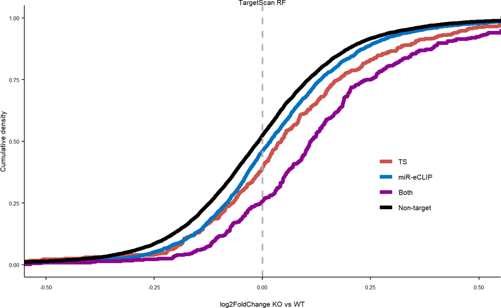

```r
##TS
TSRPFplot <- ggplot(RPF, aes(as.numeric(log2FoldChange), colour=factor(targetscan,
                                                                        levels = c("TS", "miR-eCLIP", "Both", "Non-target")))) +
  stat_ecdf(geom="step", linewidth=2) +
  geom_vline(xintercept = 0, linewidth=1, linetype="dashed", colour=farbeneg) +
  scale_colour_manual(values = c(farbe3, farbe1, RPFncol, "black")) +
  coord_cartesian(xlim = c(-xlim, xlim)) +
  theme_paper() +
  scale_y_continuous("Cumulative density") + scale_x_continuous("log2FoldChange KO vs WT") +
  ggtitle("TargetScan RF")

TSRPFplot
```

```r
pdf("MT_ECDF_RNA.pdf", width=2, height = 2)
MTRNAplot
dev.off()
```

```r
pdf("TS_ECDF_RNA.pdf", width=2, height = 2)
TSRNAplot
dev.off()
```

```r
pdf("MT_ECDF_RPF.pdf", width=2, height = 2)
MTRPFplot
dev.off()
```

```r
pdf("TS_ECDF_RPF.pdf", width=2, height = 2)
TSRPFplot
dev.off()
```

### 5.0.4 Each line with all targets, duplicates!!

### 5.0.5 partial lists

```r
MTod <- MTab[!duplicated(MTab$Target), "Target"]

eclipod <- largetframe[!duplicated(largetframe$geneName), "geneName"]

TSod <- TS[!duplicated(TS$`Target gene`), "Target gene"]

elcipTSd <- largetframe[!duplicated(largetframe$geneName) &
              (largetframe$geneName %in% TS$`Target gene`), "geneName"]

eclipMTd <- largetframe[!duplicated(largetframe$geneName) &
              (largetframe$geneName %in% MTab$Target), "geneName"]

TSMTd <- TS[!duplicated(TS$`Target gene`) &
            (TS$`Target gene` %in% MTab$Target), "Target gene"]

eclipTSMTd <- largetframe[!duplicated(largetframe$geneName) &
              (largetframe$geneName %in% TS$`Target gene`) &
              (largetframe$geneName %in% MTab$Target), "geneName"]
```

### 5.0.6 Add IDs to RNA and RF

```r
#RNA
MTofRNA <- RNA[RNA$gene_symbol %in% MTod,]
MTofRNA$vennfraction <- "MT"

eclipofRNA <- RNA[RNA$gene_symbol %in% eclipod,]
eclipofRNA$vennfraction <- "eCLIP"

TSofRNA <- RNA[RNA$gene_symbol %in% TSod,]
TSofRNA$vennfraction <- "TS"

elcipTSfRNA <- RNA[RNA$gene_symbol %in% elcipTSd,]
elcipTSfRNA$vennfraction <- "eCLIP & TS"

eclipMTfRNA <- RNA[RNA$gene_symbol %in% eclipMTd,]
eclipMTfRNA$vennfraction <- "eCLIP & MT"

TSMTfRNA <- RNA[RNA$gene_symbol %in% TSMTd,]
TSMTfRNA$vennfraction <- "TS & MT"

eclipTSMTfRNA <- RNA[RNA$gene_symbol %in% eclipTSMTd,]
eclipTSMTfRNA$vennfraction <- "eCLIP, TS & MT"

nontargetsRNA <- RNA[!(RNA$gene_symbol %in% MTod) &
                       !(RNA$gene_symbol %in% eclipod) &
                       !(RNA$gene_symbol %in% TSod),]
nontargetsRNA$vennfraction <- "Non-target"

RNAtotal <- rbind(MTofRNA, eclipofRNA, TSofRNA, elcipTSfRNA, eclipMTfRNA, TSMTfRNA, eclipTSMTfRNA, nontargetsRNA)
table(RNAtotal$vennfraction)
```

```
##
##          eCLIP     eCLIP & MT     eCLIP & TS eCLIP, TS & MT             MT
##           2160            143            352             73            391
##     Non-target             TS        TS & MT
##          10524            775            127
```

```r
#RPF
MTofRPF <- RPF[RPF$gene_symbol %in% MTod,]
MTofRPF$vennfraction <- "MT"

eclipofRPF <- RPF[RPF$gene_symbol %in% eclipod,]
eclipofRPF$vennfraction <- "eCLIP"

TSofRPF <- RPF[RPF$gene_symbol %in% TSod,]
TSofRPF$vennfraction <- "TS"

elcipTSfRPF <- RPF[RPF$gene_symbol %in% elcipTSd,]
elcipTSfRPF$vennfraction <- "eCLIP & TS"

eclipMTfRPF <- RPF[RPF$gene_symbol %in% eclipMTd,]
eclipMTfRPF$vennfraction <- "eCLIP & MT"

TSMTfRPF <- RPF[RPF$gene_symbol %in% TSMTd,]
TSMTfRPF$vennfraction <- "TS & MT"

eclipTSMTfRPF <- RPF[RPF$gene_symbol %in% eclipTSMTd,]
eclipTSMTfRPF$vennfraction <- "eCLIP, TS & MT"

nontargetsRPF <- RPF[!(RPF$gene_symbol %in% MTod) &
                       !(RPF$gene_symbol %in% eclipod) &
                       !(RPF$gene_symbol %in% TSod),]
nontargetsRPF$vennfraction <- "Non-target"

RPFtotal <- rbind(MTofRPF, eclipofRPF, TSofRPF, elcipTSfRPF, eclipMTfRPF, TSMTfRPF, eclipTSMTfRPF, nontargetsRPF)
table(RPFtotal$vennfraction)
```

```
##
##          eCLIP     eCLIP & MT     eCLIP & TS eCLIP, TS & MT             MT
##           2147            143            352             73            365
##     Non-target             TS        TS & MT
##           8649            753            123
```

### 5.0.7 ECDF plots

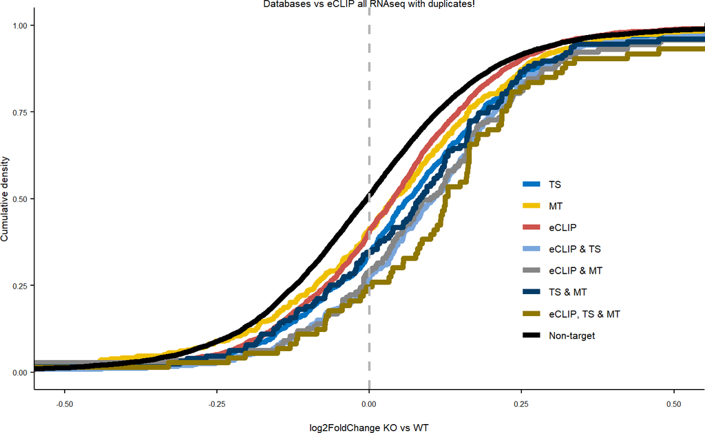

```r
#limits
xlim <- 0.5
#RNA
OLaecdfRNAd <- ggplot(RNAtotal, aes(as.numeric(log2FoldChange), colour=factor(vennfraction,
                                                                        levels = c("TS", "MT", "eCLIP", "eCLIP & TS", "eCLIP & MT", "TS & MT", "eCLIP, TS & MT", "Non-target")))) +
  stat_ecdf(geom="step", linewidth=2) +
  geom_vline(xintercept = 0, linewidth=1, linetype="dashed", colour=farbeneg) +
  scale_colour_manual(values = c(farbe1, farbe2, farbe3, farbe4, farbe5, farbe6, farbe7, "black")) +
  coord_cartesian(xlim = c(-xlim, xlim)) +
  theme_paper() +
  scale_y_continuous("Cumulative density") + scale_x_continuous("log2FoldChange KO vs WT") +
  ggtitle("Databases vs eCLIP all RNAseq with duplicates!")

OLaecdfRNAd
```

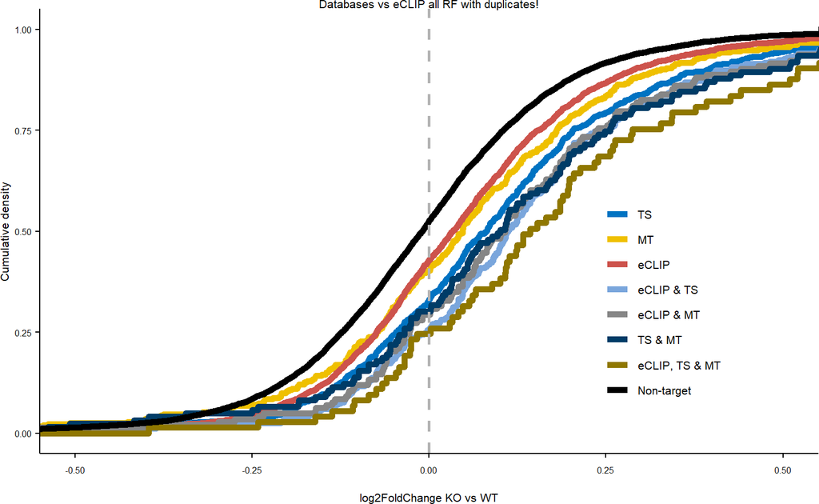

```r
OLaecdfRPFd <- ggplot(RPFtotal, aes(as.numeric(log2FoldChange), colour=factor(vennfraction,
                                                                        levels = c("TS", "MT", "eCLIP", "eCLIP & TS", "eCLIP & MT", "TS & MT", "eCLIP, TS & MT", "Non-target")))) +
  stat_ecdf(geom="step", linewidth=2) +
  geom_vline(xintercept = 0, linewidth=1, linetype="dashed", colour=farbeneg) +
  scale_colour_manual(values = c(farbe1, farbe2, farbe3, farbe4, farbe5, farbe6, farbe7, "black")) +
  coord_cartesian(xlim = c(-xlim, xlim)) +
  theme_paper() +
  scale_y_continuous("Cumulative density") + scale_x_continuous("log2FoldChange KO vs WT") +
  ggtitle("Databases vs eCLIP all RF with duplicates!")

OLaecdfRPFd
```

```r
pdf("TS_MT_eCLIP_all_ECDF_RNA_with_duplicates.pdf", width=2, height = 2)
OLaecdfRNAd
dev.off()
```

```r
pdf("TS_MT_eCLIP_all_ECDF_RF_with_duplicates.pdf", width=2, height = 2)
OLaecdfRPFd
dev.off()
```

# 6 3’UTR

Overlap of only 3’UTRs from eCLIP with databases

## 6.1 number of MREs by region

Since we want to only genes with single MREs, we calculate the numbers here

```r
numframe <- as.data.frame(table(largetframe$geneName))
colnames(numframe) <- c("geneName", "number_MREs_total")
num3utr <-  as.data.frame(table(largetframe[largetframe$region == "utr3" , "geneName"]))
colnames(num3utr) <- c("geneName", "number_MREs_3utr")
numcds <-  as.data.frame(table(largetframe[largetframe$region == "cds" , "geneName"]))
colnames(numcds) <- c("geneName", "number_MREs_cds")


numframe <- left_join(numframe, num3utr, by="geneName")
numframe <- left_join(numframe, numcds, by="geneName")

head(numframe)
```

```
##        geneName number_MREs_total number_MREs_3utr number_MREs_cds
## 1 1600014C10Rik                 1                1              NA
## 2 1810013L24Rik                 1               NA               1
## 3 1810037I17Rik                 1                1              NA
## 4 1810058I24Rik                 2               NA              NA
## 5 2010315B03Rik                 2               NA               1
## 6 2410002F23Rik                 2                1              NA
```

```r
singframe <- numframe[numframe$number_MREs_total == 1,]
singframe$region[singframe$number_MREs_3utr == 1] <- "utr3"
singframe$region[singframe$number_MREs_cds == 1] <- "cds"

singframe$geneName <- as.character(singframe$geneName)
singframe <- singframe[!(singframe$geneName=="NA"),]
head(singframe)
```

```
##         geneName number_MREs_total number_MREs_3utr number_MREs_cds region
## 1  1600014C10Rik                 1                1              NA   utr3
## 2  1810013L24Rik                 1               NA               1    cds
## 3  1810037I17Rik                 1                1              NA   utr3
## 7  2410004B18Rik                 1                1              NA   utr3
## 9  2610021A01Rik                 1               NA               1    cds
## 10 2700049A03Rik                 1               NA               1    cds
```

## 6.2 Venn lists 3’UTR

```r
utr3list <- list(TS[!duplicated(TS$`Target gene`), "Target gene"],
               MTab[!duplicated(MTab$Target), "Target"],
               singframe[singframe$region %in% c("utr3"), "geneName"])
names(utr3list) <- c("TargetScan", "miRTarBase", "miR-eCLIP")
```

## 6.3 Venn 3’UTR

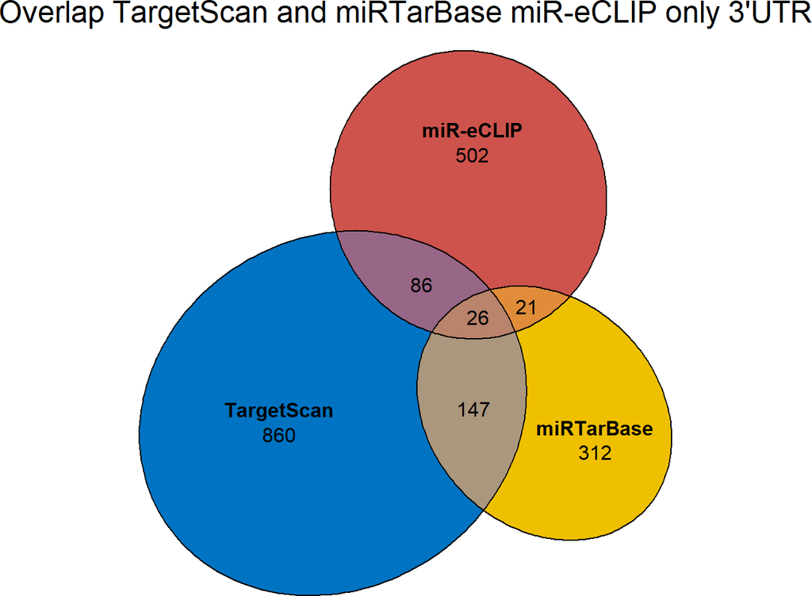

```r
plot(euler(utr3list, shape="ellipse"), quantities = T, fills=c(farbe1, farbe2, farbe3), main = "Overlap TargetScan and miRTarBase miR-eCLIP only 3'UTR")
```

```r
pdf("Venn_Overlap TargetScan miRTarBase and miR-eCLIP 3UTR.pdf", width = 3, height = 3)
plot(euler(utr3list, shape="ellipse"), quantities = T, fills=c(farbe1, farbe2, farbe3), main = "Overlap TargetScan and miRTarBase miR-eCLIP only 3'UTR")
dev.off()
```

## 6.4 ID for ECDf 3’UTR

```r
# easiert to replace like this
largetframe3utr <- singframe[singframe$region %in% c("utr3"),]


MTo3utr <- MTab[!duplicated(MTab$Target) &
              !(MTab$Target %in% largetframe3utr$geneName) &
              !(MTab$Target %in% TS$`Target gene`), "Target"]

eclipo3utr <- largetframe3utr[!duplicated(largetframe3utr$geneName) &
              !(largetframe3utr$geneName %in% TS$`Target gene`) &
              !(largetframe3utr$geneName %in% MTab$Target), "geneName"]

TSo3utr <- TS[!duplicated(TS$`Target gene`) &
            !(TS$`Target gene` %in% largetframe3utr$geneName) &
            !(TS$`Target gene` %in% MTab$Target), "Target gene"]

elcipTS3utr <- largetframe3utr[!duplicated(largetframe3utr$geneName) &
              (largetframe3utr$geneName %in% TS$`Target gene`) &
              !(largetframe3utr$geneName %in% MTab$Target), "geneName"]

eclipMT3utr <- largetframe3utr[!duplicated(largetframe3utr$geneName) &
              !(largetframe3utr$geneName %in% TS$`Target gene`) &
              (largetframe3utr$geneName %in% MTab$Target), "geneName"]

TSMT3utr <- TS[!duplicated(TS$`Target gene`) &
            !(TS$`Target gene` %in% largetframe3utr$geneName) &
            (TS$`Target gene` %in% MTab$Target), "Target gene"]

eclipTSMT3utr<- largetframe3utr[!duplicated(largetframe3utr$geneName) &
              (largetframe3utr$geneName %in% TS$`Target gene`) &
              (largetframe3utr$geneName %in% MTab$Target), "geneName"]


# Add IDS to RNA and RF
RNA$Overlap_3utr <- "Non-target"
RNA$Overlap_3utr[RNA$gene_symbol %in% MTo3utr] <- "MT"
RNA$Overlap_3utr[RNA$gene_symbol %in% eclipo3utr] <- "eCLIP"
RNA$Overlap_3utr[RNA$gene_symbol %in% TSo3utr] <- "TS"
RNA$Overlap_3utr[RNA$gene_symbol %in% elcipTS3utr] <- "eCLIP & TS"
RNA$Overlap_3utr[RNA$gene_symbol %in% eclipMT3utr] <- "eCLIP & MT"
RNA$Overlap_3utr[RNA$gene_symbol %in% TSMT3utr] <- "TS & MT"
RNA$Overlap_3utr[RNA$gene_symbol %in% eclipTSMT3utr] <- "eCLIP, TS & MT"

RPF$Overlap_3utr <- "Non-target"
RPF$Overlap_3utr[RPF$gene_symbol %in% MTo3utr] <- "MT"
RPF$Overlap_3utr[RPF$gene_symbol %in% eclipo3utr] <- "eCLIP"
RPF$Overlap_3utr[RPF$gene_symbol %in% TSo3utr] <- "TS"
RPF$Overlap_3utr[RPF$gene_symbol %in% elcipTS3utr] <- "eCLIP & TS"
RPF$Overlap_3utr[RPF$gene_symbol %in% eclipMT3utr] <- "eCLIP & MT"
RPF$Overlap_3utr[RPF$gene_symbol %in% TSMT3utr] <- "TS & MT"
RPF$Overlap_3utr[RPF$gene_symbol %in% eclipTSMT3utr] <- "eCLIP, TS & MT"
```

## 6.5 ECDF 3’UTR

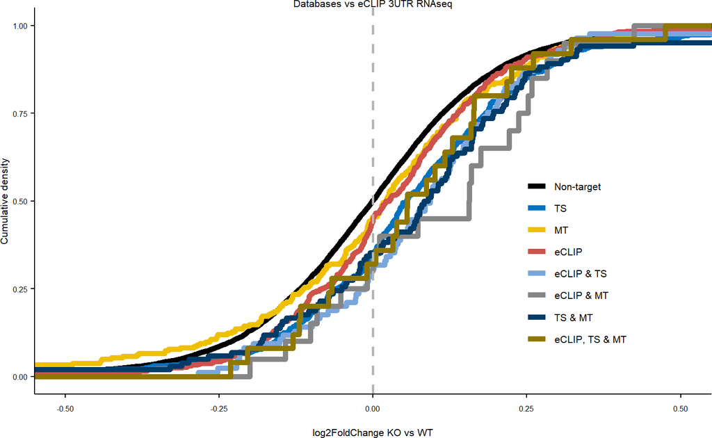

```r
#RNA
OL3utrecdfRNA <- ggplot(RNA, aes(as.numeric(log2FoldChange), colour=factor(Overlap_3utr,
                                                                        levels = c("Non-target", "TS", "MT", "eCLIP", "eCLIP & TS", "eCLIP & MT", "TS & MT", "eCLIP, TS & MT")))) +
  stat_ecdf(geom="step", linewidth=2) +
  geom_vline(xintercept = 0, linewidth=1, linetype="dashed", colour=farbeneg) +
  scale_colour_manual(values = c("black", farbe1, farbe2, farbe3, farbe4, farbe5, farbe6, farbe7)) +
  coord_cartesian(xlim = c(-xlim, xlim)) +
  theme_paper() +
  scale_y_continuous("Cumulative density") + scale_x_continuous("log2FoldChange KO vs WT") +
  ggtitle("Databases vs eCLIP 3UTR RNAseq")

OL3utrecdfRNA
```

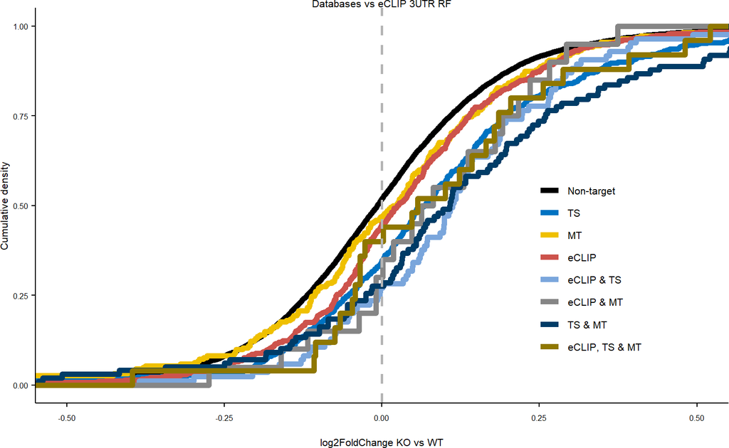

```r
OL3utrecdfRPF <- ggplot(RPF, aes(as.numeric(log2FoldChange), colour=factor(Overlap_3utr,
                                                                        levels = c("Non-target", "TS", "MT", "eCLIP", "eCLIP & TS", "eCLIP & MT", "TS & MT", "eCLIP, TS & MT")))) +
  stat_ecdf(geom="step", linewidth=2) +
  geom_vline(xintercept = 0, linewidth=1, linetype="dashed", colour=farbeneg) +
  scale_colour_manual(values = c("black", farbe1, farbe2, farbe3, farbe4, farbe5, farbe6, farbe7)) +
  coord_cartesian(xlim = c(-xlim, xlim)) +
  theme_paper() +
  scale_y_continuous("Cumulative density") + scale_x_continuous("log2FoldChange KO vs WT") +
  ggtitle("Databases vs eCLIP 3UTR RF")

OL3utrecdfRPF
```

```r
pdf("TS_MT_eCLIP_3utr_ECDF_RNA.pdf", width=2, height = 2)
OL3utrecdfRNA
dev.off()
```

```r
pdf("TS_MT_eCLIP_3utr_ECDF_RF.pdf", width=2, height = 2)
OL3utrecdfRPF
dev.off()
```

# 7 CDS

Overlap of only CDSs from eCLIP with databases

## 7.1 Venn lists CDS

```r
cdslist <- list(TS[!duplicated(TS$`Target gene`), "Target gene"],
               MTab[!duplicated(MTab$Target), "Target"],
               singframe[singframe$region %in% c("cds"), "geneName"])
names(cdslist) <- c("TargetScan", "miRTarBase", "miR-eCLIP")
```

## 7.2 Venn CDS

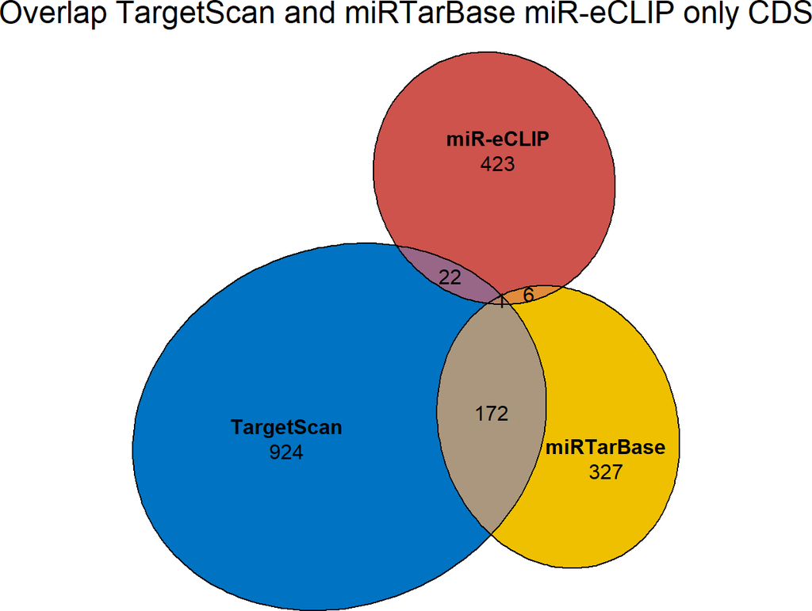

```r
plot(euler(cdslist, shape="ellipse"), quantities = T, fills=c(farbe1, farbe2, farbe3), main = "Overlap TargetScan and miRTarBase miR-eCLIP only CDS")
```

```r
pdf("Venn_Overlap TargetScan miRTarBase and miR-eCLIP CDS.pdf", width = 3, height = 3)
plot(euler(cdslist, shape="ellipse"), quantities = T, fills=c(farbe1, farbe2, farbe3), main = "Overlap TargetScan and miRTarBase miR-eCLIP only CDS")
dev.off()
```

## 7.3 ID for ECDf CDS

```r
# easiert to replace like this
largetframecds <- singframe[singframe$region %in% c("cds"),]


MTocds <- MTab[!duplicated(MTab$Target) &
              !(MTab$Target %in% largetframecds$geneName) &
              !(MTab$Target %in% TS$`Target gene`), "Target"]

eclipocds <- largetframecds[!duplicated(largetframecds$geneName) &
              !(largetframecds$geneName %in% TS$`Target gene`) &
              !(largetframecds$geneName %in% MTab$Target), "geneName"]

TSocds <- TS[!duplicated(TS$`Target gene`) &
            !(TS$`Target gene` %in% largetframecds$geneName) &
            !(TS$`Target gene` %in% MTab$Target), "Target gene"]

elcipTScds <- largetframecds[!duplicated(largetframecds$geneName) &
              (largetframecds$geneName %in% TS$`Target gene`) &
              !(largetframecds$geneName %in% MTab$Target), "geneName"]

eclipMTcds <- largetframecds[!duplicated(largetframecds$geneName) &
              !(largetframecds$geneName %in% TS$`Target gene`) &
              (largetframecds$geneName %in% MTab$Target), "geneName"]

TSMTcds <- TS[!duplicated(TS$`Target gene`) &
            !(TS$`Target gene` %in% largetframecds$geneName) &
            (TS$`Target gene` %in% MTab$Target), "Target gene"]

eclipTSMTcds<- largetframecds[!duplicated(largetframecds$geneName) &
              (largetframecds$geneName %in% TS$`Target gene`) &
              (largetframecds$geneName %in% MTab$Target), "geneName"]


# Add IDS to RNA and RF
RNA$Overlap_cds <- "Non-target"
RNA$Overlap_cds[RNA$gene_symbol %in% MTocds] <- "MT"
RNA$Overlap_cds[RNA$gene_symbol %in% eclipocds] <- "eCLIP"
RNA$Overlap_cds[RNA$gene_symbol %in% TSocds] <- "TS"
RNA$Overlap_cds[RNA$gene_symbol %in% elcipTScds] <- "eCLIP & TS"
RNA$Overlap_cds[RNA$gene_symbol %in% eclipMTcds] <- "eCLIP & MT"
RNA$Overlap_cds[RNA$gene_symbol %in% TSMTcds] <- "TS & MT"
RNA$Overlap_cds[RNA$gene_symbol %in% eclipTSMTcds] <- "eCLIP, TS & MT"

RPF$Overlap_cds <- "Non-target"
RPF$Overlap_cds[RPF$gene_symbol %in% MTocds] <- "MT"
RPF$Overlap_cds[RPF$gene_symbol %in% eclipocds] <- "eCLIP"
RPF$Overlap_cds[RPF$gene_symbol %in% TSocds] <- "TS"
RPF$Overlap_cds[RPF$gene_symbol %in% elcipTScds] <- "eCLIP & TS"
RPF$Overlap_cds[RPF$gene_symbol %in% eclipMTcds] <- "eCLIP & MT"
RPF$Overlap_cds[RPF$gene_symbol %in% TSMTcds] <- "TS & MT"
RPF$Overlap_cds[RPF$gene_symbol %in% eclipTSMTcds] <- "eCLIP, TS & MT"
```

## 7.4 ECDF CDS

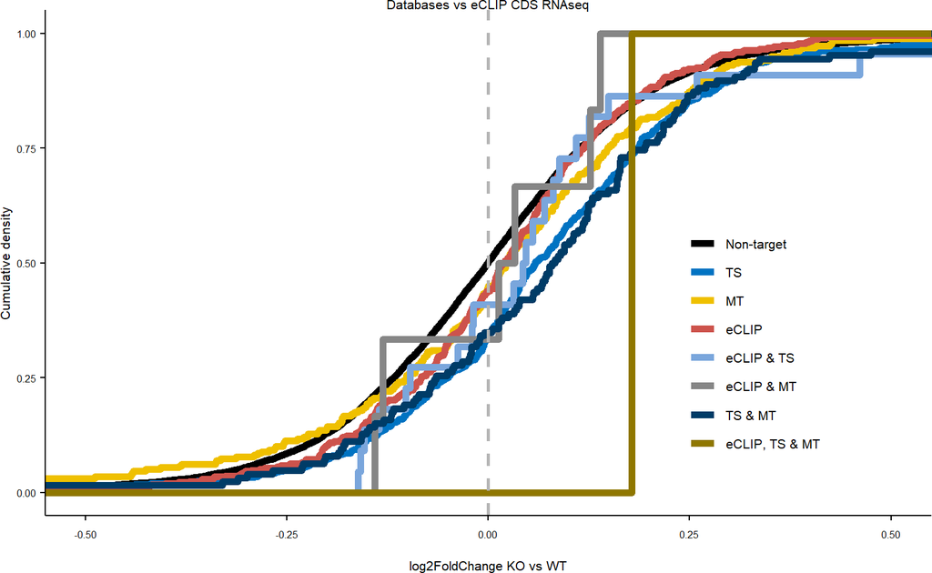

```r
#RNA
OLcdsecdfRNA <- ggplot(RNA, aes(as.numeric(log2FoldChange), colour=factor(Overlap_cds,
                                                                        levels = c("Non-target", "TS", "MT", "eCLIP", "eCLIP & TS", "eCLIP & MT", "TS & MT", "eCLIP, TS & MT")))) +
  stat_ecdf(geom="step", linewidth=2) +
  geom_vline(xintercept = 0, linewidth=1, linetype="dashed", colour=farbeneg) +
  scale_colour_manual(values = c("black", farbe1, farbe2, farbe3, farbe4, farbe5, farbe6, farbe7)) +
  coord_cartesian(xlim = c(-xlim, xlim)) +
  theme_paper() +
  scale_y_continuous("Cumulative density") + scale_x_continuous("log2FoldChange KO vs WT") +
  ggtitle("Databases vs eCLIP CDS RNAseq")

OLcdsecdfRNA
```

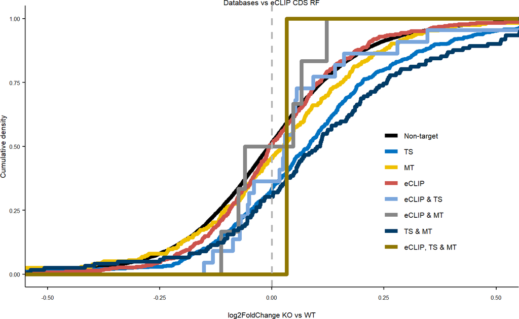

```r
OLcdsecdfRPF <- ggplot(RPF, aes(as.numeric(log2FoldChange), colour=factor(Overlap_cds,
                                                                        levels = c("Non-target", "TS", "MT", "eCLIP", "eCLIP & TS", "eCLIP & MT", "TS & MT", "eCLIP, TS & MT")))) +
  stat_ecdf(geom="step", linewidth=2) +
  geom_vline(xintercept = 0, linewidth=1, linetype="dashed", colour=farbeneg) +
  scale_colour_manual(values = c("black", farbe1, farbe2, farbe3, farbe4, farbe5, farbe6, farbe7)) +
  coord_cartesian(xlim = c(-xlim, xlim)) +
  theme_paper() +
  scale_y_continuous("Cumulative density") + scale_x_continuous("log2FoldChange KO vs WT") +
  ggtitle("Databases vs eCLIP CDS RF")

OLcdsecdfRPF
```

```r
pdf("TS_MT_eCLIP_cds_ECDF_RNA.pdf", width=2, height = 2)
OLcdsecdfRNA
dev.off()
```

```r
pdf("TS_MT_eCLIP_cds_ECDF_RF.pdf", width=2, height = 2)
OLcdsecdfRPF
dev.off()
```

# 8 MT eCLIP

## 8.1 split into weak and strong

```r
MTab$Type <- "weak"
MTab$Type[(MTab[,6] + MTab[,7] + MTab[,8])  > 0] <- "strong"
```

## 8.2 all

```r
mtalllist <- list(MTab[!duplicated(MTab$Target), "Target"],
               singframe[, "geneName"])
names(mtalllist) <- c("miRTarBase", "miR-eCLIP")
```

### 8.2.1 Venn all mt

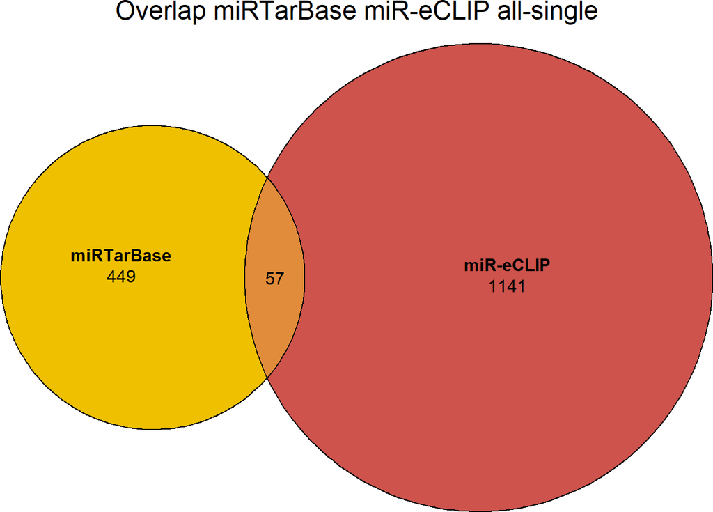

```r
plot(euler(mtalllist, shape="ellipse"), quantities = T, fills=c(farbe2, farbe3), main = "Overlap miRTarBase miR-eCLIP all-single")
```

```r
pdf("Venn_Overlap miRTarBase and miR-eCLIP all-single.pdf", width = 3, height = 3)
plot(euler(mtalllist, shape="ellipse"), quantities = T, fills=c(farbe2, farbe3), main = "Overlap miRTarBase miR-eCLIP all-single")
dev.off()
```

## 8.3 strong

```r
mtstronglist <- list(MTab[!duplicated(MTab$Target) & MTab$Type == "strong", "Target"],
               singframe[, "geneName"])
names(mtstronglist) <- c("miRTarBase", "miR-eCLIP")
```

### 8.3.1 Venn strong mt

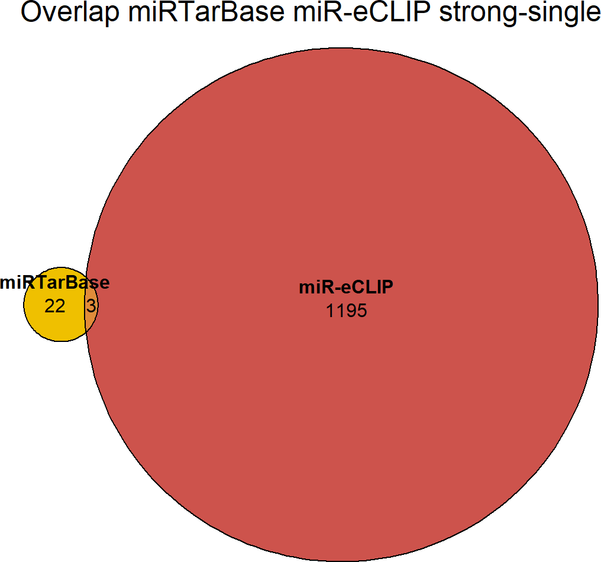

```r
plot(euler(mtstronglist, shape="ellipse"), quantities = T, fills=c(farbe2, farbe3), main = "Overlap miRTarBase miR-eCLIP strong-single")
```

```r
pdf("Venn_Overlap miRTarBase and miR-eCLIP strong-single.pdf", width = 3, height = 3)
plot(euler(mtstronglist, shape="ellipse"), quantities = T, fills=c(farbe2, farbe3), main = "Overlap miRTarBase miR-eCLIP strong-single")
dev.off()
```

## 8.4 weak

```r
mtweaklist <- list(MTab[!duplicated(MTab$Target) & MTab$Type == "weak", "Target"],
               singframe[, "geneName"])
names(mtweaklist) <- c("miRTarBase", "miR-eCLIP")
```

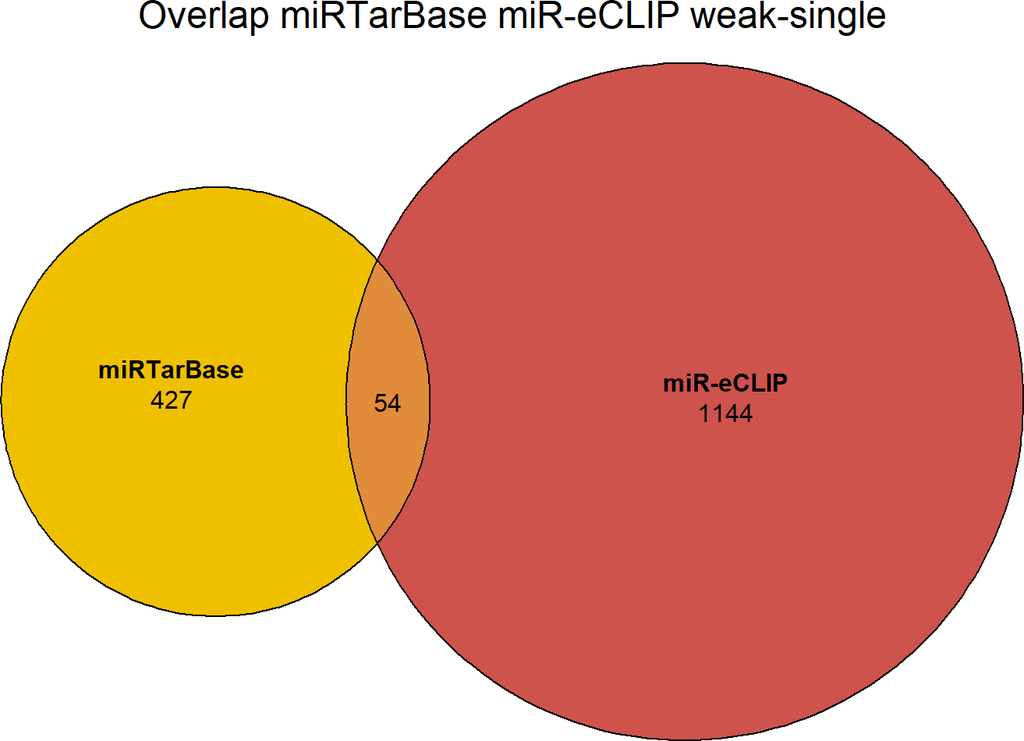

```r
plot(euler(mtweaklist, shape="ellipse"), quantities = T, fills=c(farbe2, farbe3), main = "Overlap miRTarBase miR-eCLIP weak-single")
```

```r
pdf("Venn_Overlap miRTarBase and miR-eCLIP weak-single.pdf", width = 3, height = 3)
plot(euler(mtweaklist, shape="ellipse"), quantities = T, fills=c(farbe2, farbe3), main = "Overlap miRTarBase miR-eCLIP weak-single")
dev.off()
```

## 8.5 ECDF plots strong weak

### 8.5.1 extra column in RNA and RF

```r
#strong

#RNA
RNA$strong <- "Non-target"
RNA$strong[RNA$gene_symbol %in% MTab[MTab$Type == "strong", "Target"] &
           !(RNA$gene_symbol %in% singframe$geneName)] <- "MT-strong"
RNA$strong[!(RNA$gene_symbol %in% MTab[MTab$Type == "strong", "Target"]) &
           (RNA$gene_symbol %in% singframe$geneName)] <- "miR-eCLIP-single"
RNA$strong[RNA$gene_symbol %in% MTab[MTab$Type == "strong", "Target"] &
           (RNA$gene_symbol %in% singframe$geneName)] <- "Overlap"

table(RNA$strong)
```

```
##
## miR-eCLIP-single        MT-strong       Non-target          Overlap
##             1162               11            12125                3
```

```r
#RF
RPF$strong <- "Non-target"
RPF$strong[RPF$gene_symbol %in% MTab[MTab$Type == "strong", "Target"] &
           !(RPF$gene_symbol %in% singframe$geneName)] <- "MT-strong"
RPF$strong[!(RPF$gene_symbol %in% MTab[MTab$Type == "strong", "Target"]) &
           (RPF$gene_symbol %in% singframe$geneName)] <- "miR-eCLIP-single"
RPF$strong[RPF$gene_symbol %in% MTab[MTab$Type == "strong", "Target"] &
           (RPF$gene_symbol %in% singframe$geneName)] <- "Overlap"

table(RPF$strong)
```

```
##
## miR-eCLIP-single        MT-strong       Non-target          Overlap
##             1154               11            10201                3
```

```r
#weak

#RNA
RNA$weak <- "Non-target"
RNA$weak[RNA$gene_symbol %in% MTab[MTab$Type == "weak", "Target"] &
           !(RNA$gene_symbol %in% singframe$geneName)] <- "MT-weak"
RNA$weak[!(RNA$gene_symbol %in% MTab[MTab$Type == "weak", "Target"]) &
           (RNA$gene_symbol %in% singframe$geneName)] <- "miR-eCLIP-single"
RNA$weak[RNA$gene_symbol %in% MTab[MTab$Type == "weak", "Target"] &
           (RNA$gene_symbol %in% singframe$geneName)] <- "Overlap"

table(RNA$weak)
```

```
##
## miR-eCLIP-single          MT-weak       Non-target          Overlap
##             1114              327            11809               51
```

```r
#RF
RPF$weak <- "Non-target"
RPF$weak[RPF$gene_symbol %in% MTab[MTab$Type == "weak", "Target"] &
           !(RPF$gene_symbol %in% singframe$geneName)] <- "MT-weak"
RPF$weak[!(RPF$gene_symbol %in% MTab[MTab$Type == "weak", "Target"]) &
           (RPF$gene_symbol %in% singframe$geneName)] <- "miR-eCLIP-single"
RPF$weak[RPF$gene_symbol %in% MTab[MTab$Type == "weak", "Target"] &
           (RPF$gene_symbol %in% singframe$geneName)] <- "Overlap"

table(RPF$weak)
```

```
##
## miR-eCLIP-single          MT-weak       Non-target          Overlap
##             1106              301             9911               51
```

### 8.5.2 plot

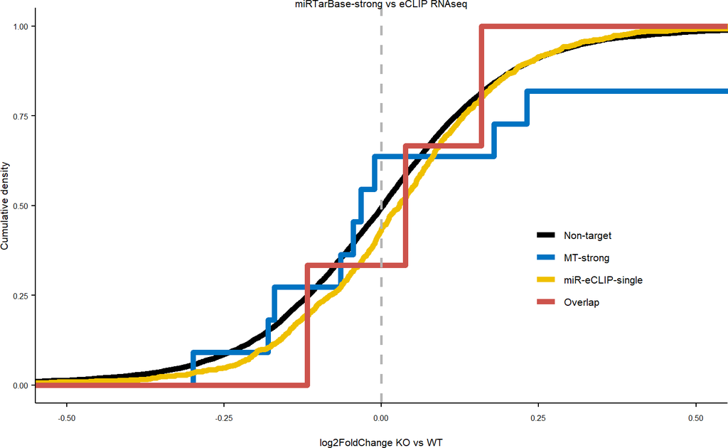

```r
# strong
#RNA
OLstrongecdfRNA <- ggplot(RNA, aes(as.numeric(log2FoldChange), colour=factor(strong,
                                                                        levels = c("Non-target", "MT-strong", "miR-eCLIP-single", "Overlap")))) +
  stat_ecdf(geom="step", linewidth=2) +
  geom_vline(xintercept = 0, linewidth=1, linetype="dashed", colour=farbeneg) +
  scale_colour_manual(values = c("black", farbe1, farbe2, farbe3)) +
  coord_cartesian(xlim = c(-xlim, xlim)) +
  theme_paper() +
  scale_y_continuous("Cumulative density") + scale_x_continuous("log2FoldChange KO vs WT") +
  ggtitle("miRTarBase-strong vs eCLIP RNAseq")

OLstrongecdfRNA
```

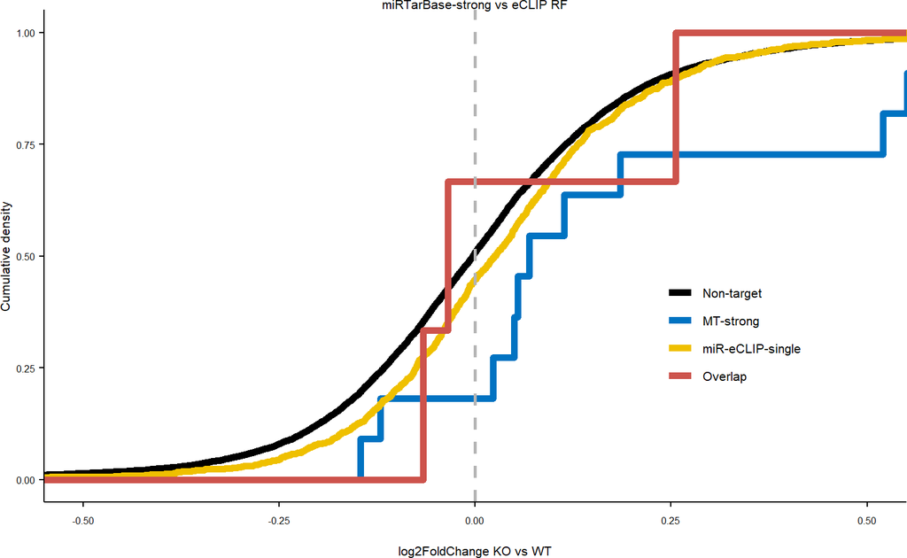

```r
OLstrongecdfRPF <- ggplot(RPF, aes(as.numeric(log2FoldChange), colour=factor(strong,
                                                                        levels = c("Non-target", "MT-strong", "miR-eCLIP-single", "Overlap")))) +
  stat_ecdf(geom="step", linewidth=2) +
  geom_vline(xintercept = 0, linewidth=1, linetype="dashed", colour=farbeneg) +
  scale_colour_manual(values = c("black", farbe1, farbe2, farbe3)) +
  coord_cartesian(xlim = c(-xlim, xlim)) +
  theme_paper() +
  scale_y_continuous("Cumulative density") + scale_x_continuous("log2FoldChange KO vs WT") +
  ggtitle("miRTarBase-strong vs eCLIP RF")

OLstrongecdfRPF
```

```r
pdf("miRTarBase-strong_vs_eCLIP_RNAseq.pdf", width=2, height = 2)
OLstrongecdfRNA
dev.off()
```

```r
pdf("miRTarBase-strong_vs_eCLIP_RF.pdf", width=2, height = 2)
OLstrongecdfRPF
dev.off()
```

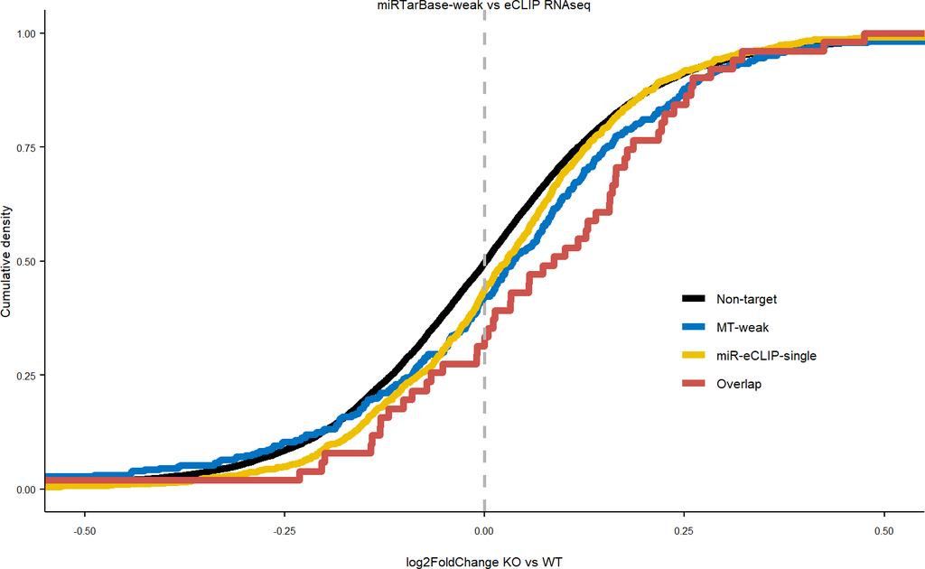

```r
# weak
#RNA
OLweakecdfRNA <- ggplot(RNA, aes(as.numeric(log2FoldChange), colour=factor(weak,
                                                                        levels = c("Non-target", "MT-weak", "miR-eCLIP-single", "Overlap")))) +
  stat_ecdf(geom="step", linewidth=2) +
  geom_vline(xintercept = 0, linewidth=1, linetype="dashed", colour=farbeneg) +
  scale_colour_manual(values = c("black", farbe1, farbe2, farbe3)) +
  coord_cartesian(xlim = c(-xlim, xlim)) +
  theme_paper() +
  scale_y_continuous("Cumulative density") + scale_x_continuous("log2FoldChange KO vs WT") +
  ggtitle("miRTarBase-weak vs eCLIP RNAseq")

OLweakecdfRNA
```

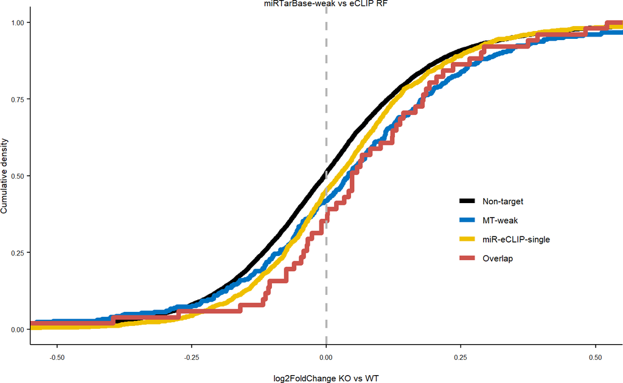

```r
OLweakecdfRPF <- ggplot(RPF, aes(as.numeric(log2FoldChange), colour=factor(weak,
                                                                        levels = c("Non-target", "MT-weak", "miR-eCLIP-single", "Overlap")))) +
  stat_ecdf(geom="step", linewidth=2) +
  geom_vline(xintercept = 0, linewidth=1, linetype="dashed", colour=farbeneg) +
  scale_colour_manual(values = c("black", farbe1, farbe2, farbe3)) +
  coord_cartesian(xlim = c(-xlim, xlim)) +
  theme_paper() +
  scale_y_continuous("Cumulative density") + scale_x_continuous("log2FoldChange KO vs WT") +
  ggtitle("miRTarBase-weak vs eCLIP RF")

OLweakecdfRPF
```

```r
pdf("miRTarBase-weak_vs_eCLIP_RNAseq.pdf", width=2, height = 2)
OLweakecdfRNA
dev.off()
```

```r
pdf("miRTarBase-weak_vs_eCLIP_RF.pdf", width=2, height = 2)
OLweakecdfRPF
dev.off()
```

# 9 Wobble

do the same graphs split by wobble (A-U non conventional seed)

```r
singwobfram <- largetframe[largetframe$geneName %in% numframe[numframe$number_MREs_total == 1, "geneName"],]
head(singwobfram)
```

```
##                seqnames start  end width strand xHits transcriptsHits  scoreSum
## 3247 ENSMUST00000182675   525  531     7      *  3266              84  9.214680
## 3248 ENSMUST00000115174  1773 1779     7      *  3267             390  7.169806
## 3252 ENSMUST00000086421  2128 2134     7      *  3271             695 15.941710
## 3257 ENSMUST00000190876  1083 1089     7      *  3276            1189 16.378710
## 3258 ENSMUST00000134566  2131 2137     7      *  3277            1575 34.430280
## 3259 ENSMUST00000066427  2065 2071     7      *  3278            1716 22.923916
##      scoreMean scoreMax                  geneType geneName             geneID
## 3247  3.071560  5.53318 mature protein_coding RNA   Pcmtd1 ENSMUSG00000051285
## 3248  1.433961  5.00224 mature protein_coding RNA    Rab23 ENSMUSG00000004768
## 3252  3.985428  7.45828 mature protein_coding RNA     Nck2 ENSMUSG00000066877
## 3257  8.189355 11.58470 mature protein_coding RNA    Creb1 ENSMUSG00000025958
## 3258  8.607570 10.93160 mature protein_coding RNA    Acsl3 ENSMUSG00000032883
## 3259  5.730979  9.10168 mature protein_coding RNA    Sp100 ENSMUSG00000026222
##      region mir_IP n_mir181 n_mir181a n_mir181b n_mir181c n_mir181d
```

[output cut: 97 more lines]

## 9.1 Venn diagrams

### 9.1.1 vlists

```r
woblist <- list(TS[!duplicated(TS$`Target gene`), "Target gene"],
               MTab[!duplicated(MTab$Target), "Target"],
               singwobfram[singwobfram$first_seed_200down.wobble %in% TRUE, "geneName"])
names(woblist) <- c("TargetScan", "miRTarBase", "miR-eCLIP")

AAlist <- list(TS[!duplicated(TS$`Target gene`), "Target gene"],
               MTab[!duplicated(MTab$Target), "Target"],
               singwobfram[singwobfram$first_seed_200down.wobble %in% FALSE, "geneName"])
names(AAlist) <- c("TargetScan", "miRTarBase", "miR-eCLIP")

NTlist <- list(TS[!duplicated(TS$`Target gene`), "Target gene"],
               MTab[!duplicated(MTab$Target), "Target"],
               singwobfram[singwobfram$first_seed_200down.wobble %in% NA, "geneName"])
names(NTlist) <- c("TargetScan", "miRTarBase", "miR-eCLIP")
```

### 9.1.2 plots

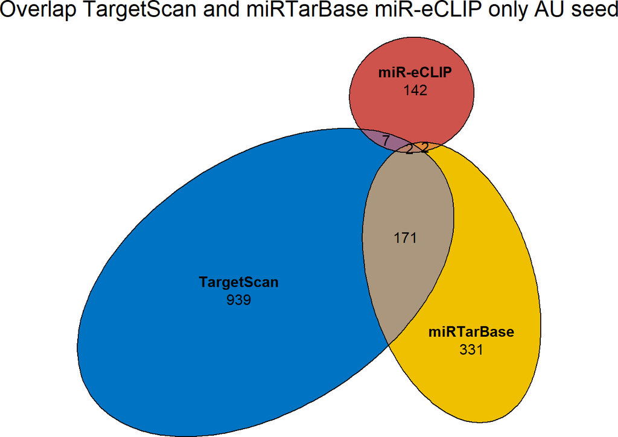

```r
plot(euler(woblist, shape="ellipse"), quantities = T, fills=c(farbe1, farbe2, farbe3), main = "Overlap TargetScan and miRTarBase miR-eCLIP only AU seed")
```

```r
pdf("Venn_Overlap TargetScan miRTarBase and miR-eCLIP Wobble.pdf", width = 3, height = 3)
plot(euler(woblist, shape="ellipse"), quantities = T, fills=c(farbe1, farbe2, farbe3), main = "Overlap TargetScan and miRTarBase miR-eCLIP only AU seed")
dev.off()
```

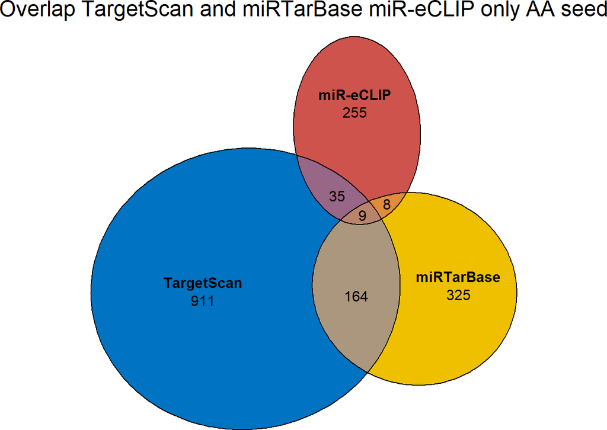

```r
plot(euler(AAlist, shape="ellipse"), quantities = T, fills=c(farbe1, farbe2, farbe3), main = "Overlap TargetScan and miRTarBase miR-eCLIP only AA seed")
```

```r
pdf("Venn_Overlap TargetScan miRTarBase and miR-eCLIP Canonical.pdf", width = 3, height = 3)
plot(euler(AAlist, shape="ellipse"), quantities = T, fills=c(farbe1, farbe2, farbe3), main = "Overlap TargetScan and miRTarBase miR-eCLIP only AA seed")
dev.off()
```

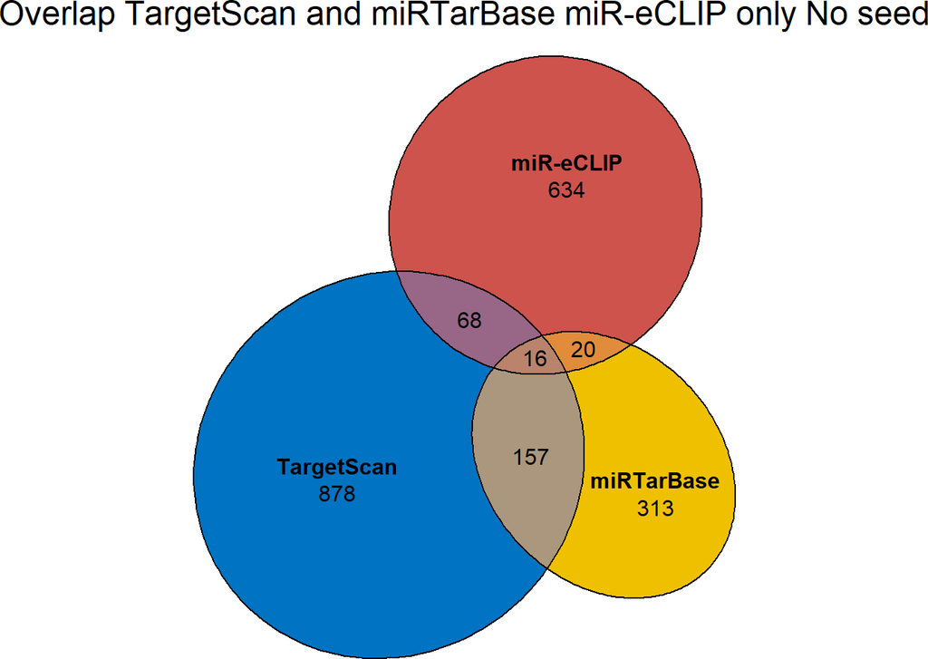

```r
plot(euler(NTlist, shape="ellipse"), quantities = T, fills=c(farbe1, farbe2, farbe3), main = "Overlap TargetScan and miRTarBase miR-eCLIP only No seed")
```

```r
pdf("Venn_Overlap TargetScan miRTarBase and miR-eCLIP NoSeed.pdf", width = 3, height = 3)
plot(euler(NTlist, shape="ellipse"), quantities = T, fills=c(farbe1, farbe2, farbe3), main = "Overlap TargetScan and miRTarBase miR-eCLIP only No seed")
dev.off()
```

## 9.2 Extra column for functional data

I think this is not finiished yet, finnish this

```r
#RNA
RNA$wobble <- "Non-target"
RNA$wobble[RNA$gene_symbol %in% singwobfram[singwobfram$first_seed_200down.wobble == TRUE, "geneName"]] <- "AU seed"
RNA$wobble[RNA$gene_symbol %in% singwobfram[singwobfram$first_seed_200down.wobble == FALSE, "geneName"]] <- "AA seed"
RNA$wobble[RNA$gene_symbol %in% singwobfram[is.na(singwobfram$first_seed_200down.wobble), "geneName"]] <- "No seed"
RNA$wobble[RNA$gene_symbol %in% numframe[numframe$number_MREs_total > 1, "geneName"]] <- "Multiple MREs"

table(RNA$wobble)
```

[output not shown]

```r
#RPF
RPF$wobble <- "Non-target"
RPF$wobble[RPF$gene_symbol %in% singwobfram[singwobfram$first_seed_200down.wobble == TRUE, "geneName"]] <- "AU seed"
RPF$wobble[RPF$gene_symbol %in% singwobfram[singwobfram$first_seed_200down.wobble == FALSE, "geneName"]] <- "AA seed"
RPF$wobble[RPF$gene_symbol %in% singwobfram[is.na(singwobfram$first_seed_200down.wobble), "geneName"]] <- "No seed"
RPF$wobble[RPF$gene_symbol %in% numframe[numframe$number_MREs_total > 1, "geneName"]] <- "Multiple MREs"

table(RPF$wobble)
```

```
##
##       AA seed       AU seed Multiple MREs       No seed    Non-target
##           295           149           990           713          9222
```

# 10 Eclip vs MT by expression

## 10.1 get overlaps of miR-eCLIp with mirTarBase

doing this again because here we can take all transcripts and not just the ones that only have one MRE

```r
#RNA
RNA$expressionvenn <- "Non-target"
RNA$expressionvenn[RNA$gene_symbol %in% largetframe$geneName] <- "miR-eCLIP"
RNA$expressionvenn[RNA$gene_symbol %in% MTab$Target] <- "miRTarBase"
RNA$expressionvenn[RNA$gene_symbol %in% largetframe$geneName & RNA$gene_symbol %in% MTab$Target] <- "Overlap"


#RPF
RPF$expressionvenn <- "Non-target"
RPF$expressionvenn[RPF$gene_symbol %in% largetframe$geneName] <- "miR-eCLIP"
RPF$expressionvenn[RPF$gene_symbol %in% MTab$Target] <- "miRTarBase"
RPF$expressionvenn[RPF$gene_symbol %in% largetframe$geneName & RPF$gene_symbol %in% MTab$Target] <- "Overlap"
```

## 10.2 plot expression levels (base mean) split by overlap

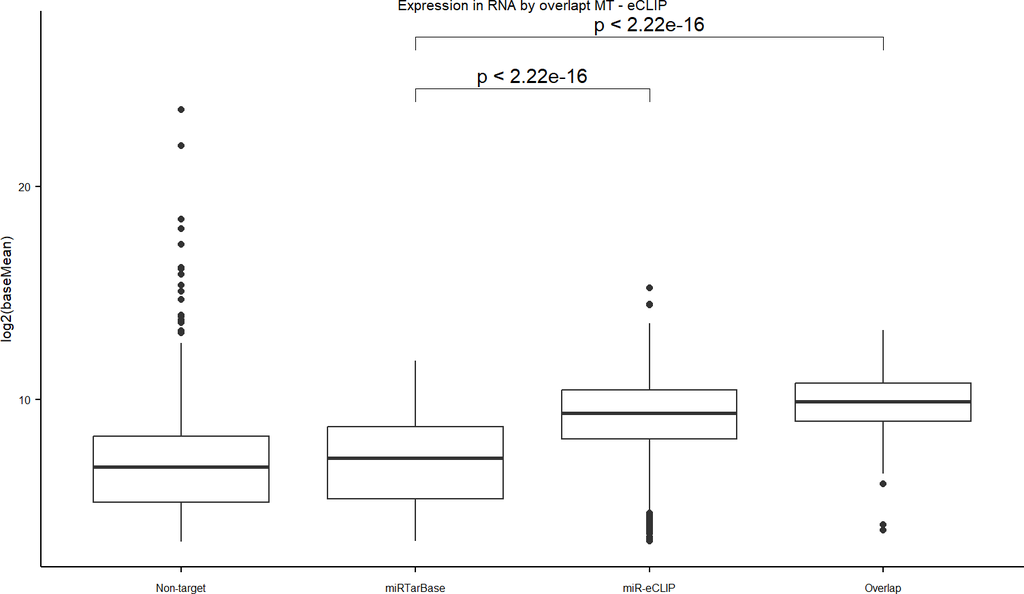

```r
mycomp <- list(c("miRTarBase", "miR-eCLIP"), c("miRTarBase", "Overlap"))

#RNA
exprplotRNA <- ggplot(RNA, aes(y=log2(baseMean), x=factor(expressionvenn, levels = c("Non-target", "miRTarBase", "miR-eCLIP", "Overlap") ))) + geom_boxplot() +
  stat_compare_means(comparisons = mycomp) +
  theme_paper() + scale_x_discrete("") +
  ggtitle("Expression in RNA by overlapt MT - eCLIP")
exprplotRNA
```

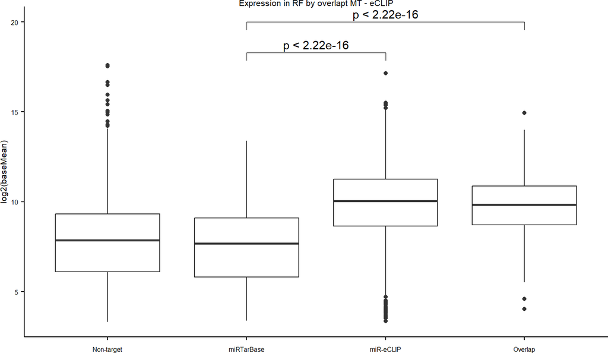

```r
#RPF
exprplotRPF <- ggplot(RPF, aes(y=log2(baseMean), x=factor(expressionvenn, levels = c("Non-target", "miRTarBase", "miR-eCLIP", "Overlap") ))) + geom_boxplot() +
  stat_compare_means(comparisons = mycomp) +
  theme_paper() + scale_x_discrete("") +
  ggtitle("Expression in RF by overlapt MT - eCLIP")
exprplotRPF
```

```r
#export
pdf("Expression in RNA by overlapt MT_eCLIP.pdf", width = 3, height = 3)
exprplotRNA
dev.off()
```

```r
pdf("Expression in RPF by overlapt MT_eCLIP.pdf", width = 3, height = 3)
exprplotRPF
dev.off()
```